# Temperatura JP x CG

```r
climas = read_csv(here::here("data/clima_cg_jp-semanal.csv"),
                  col_types = "cTdddddd")

glimpse(climas)
```

```
## Observations: 2,748
## Variables: 8
## $ cidade <chr> "Campina Grande", "Campina Grande", "Campina Grande", "...
## $ semana <dttm> 1992-12-27, 1993-01-03, 1993-01-10, 1993-01-31, 1993-0...
## $ tmedia <dbl> 26.13333, 26.11905, 25.76667, 25.74000, 26.31429, 26.28...
## $ tmax   <dbl> 30.4, 32.4, 32.2, 32.0, 32.7, 32.7, 32.3, 32.3, 32.1, 3...
## $ tmin   <dbl> 20.7, 19.3, 19.7, 19.9, 19.6, 20.0, 20.4, 21.2, 19.0, 1...
## $ chuva  <dbl> 0.0, 0.0, 0.0, 0.4, 0.3, 0.0, 4.9, 0.0, 0.0, 6.1, 0.4, ...
## $ mes    <dbl> 12, 1, 1, 1, 2, 2, 2, 2, 10, 11, 11, 11, 11, 12, 12, 12...
## $ ano    <dbl> 1992, 1993, 1993, 1993, 1993, 1993, 1993, 1993, 1993, 1...
```

## Temperatura

### Onde é mais quente?

Analisando as três medidas de temperatura por semanas, média, máximo e mínimo, temos uma inconclusividade nas temperaturas máximas, onde Campina Grande tem bastante marcações em um espectro mais variado que João Pessoa.

Em relação as temperaturas mínimas, podemos ver que na maioria das marcações, João Pessoa marca maiores mínimas que Campina Grande. Isso pode ser visto também quanto às médias marcadas.

Assim, podemos assumir que João Pessoa é uma cidade mais quente que Campina Grande, apesar de Campina Grande marcar picos de calor mais extremos em partes do ano.

```r
climas_long <- melt(climas %>% select(cidade, tmedia, tmax, tmin))
head(climas_long)
```

```
##           cidade variable    value
## 1 Campina Grande   tmedia 26.13333
## 2 Campina Grande   tmedia 26.11905
## 3 Campina Grande   tmedia 25.76667
## 4 Campina Grande   tmedia 25.74000
## 5 Campina Grande   tmedia 26.31429
## 6 Campina Grande   tmedia 26.28571
```

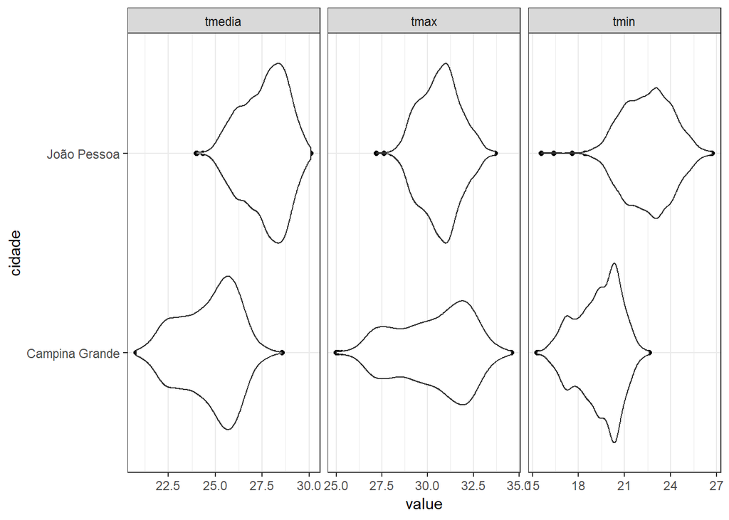

```r
ggplot(climas_long, aes(y=cidade, x=value)) + geom_point() + geom_violinh() + facet_grid(~variable, scales="free_x")
```

### As temperaturas máximas semanais (o pico do calor) são tão diferentes quanto as médias? Mais?

```r
climas_long <- melt(climas %>% select(cidade, tmedia, tmax))
head(climas_long)
```

```
##           cidade variable    value
## 1 Campina Grande   tmedia 26.13333
## 2 Campina Grande   tmedia 26.11905
## 3 Campina Grande   tmedia 25.76667
## 4 Campina Grande   tmedia 25.74000
## 5 Campina Grande   tmedia 26.31429
## 6 Campina Grande   tmedia 26.28571
```

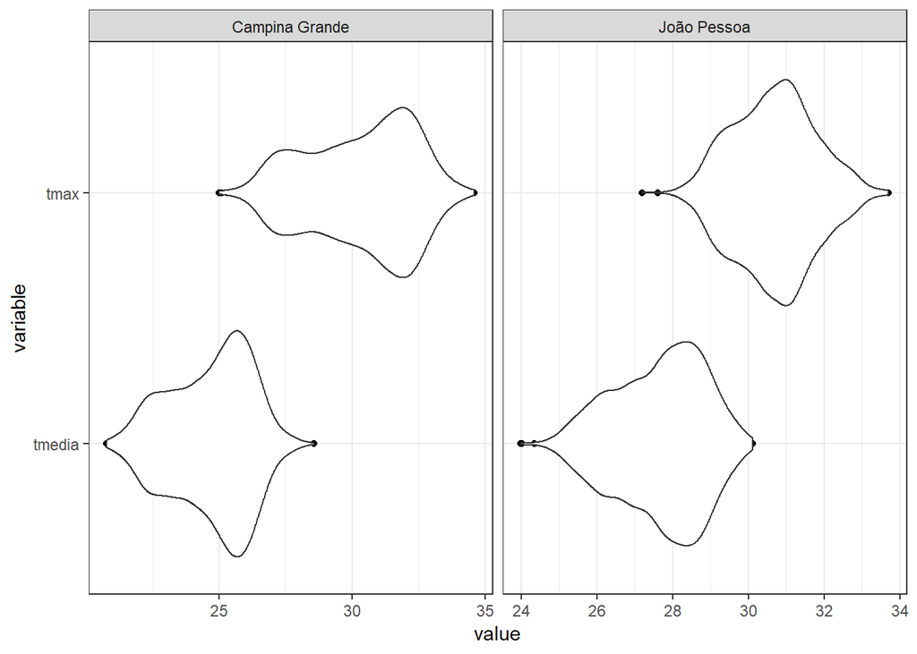

```r
ggplot(climas_long, aes(y=variable, x=value)) + geom_point() + geom_violinh() + facet_grid(~cidade, scales="free_x")
```

## Chuva

### No geral, onde chove mais?

Quando olhamos a distribuição de chuvas nas duas cidades, podemos ver uma base mais larga na cidade de Campina Grande, indicando maior quantidade de períodos de estiagem na cidade. Em João Pessoa, o centro da distribuição é mais longo e grosso, indicando mais períodos de chuva na cidade, e com chuvas mais fortes que em Campina Grande. Tudo isso indica, que João Pessoa apresenta mais chuvas que Campina Grande.

```r
climas_long <- melt(climas %>% select(cidade, chuva))
head(climas_long)
```

```
##           cidade variable value
## 1 Campina Grande    chuva   0.0
## 2 Campina Grande    chuva   0.0
## 3 Campina Grande    chuva   0.0
## 4 Campina Grande    chuva   0.4
## 5 Campina Grande    chuva   0.3
## 6 Campina Grande    chuva   0.0
```

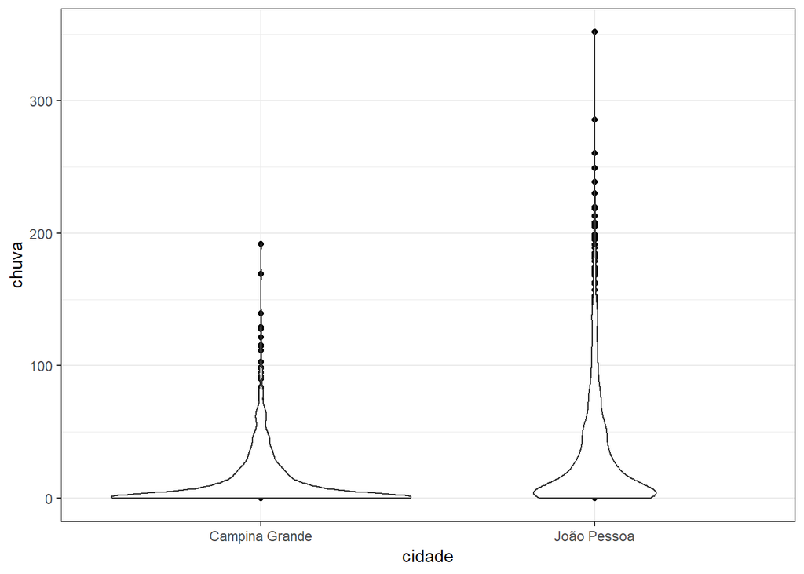

```r
ggplot(climas, aes(x=cidade, y=chuva)) + geom_point() + geom_violin()
```

### A distribuição é diferente em meses específicos?

Sim, outono e inverno apresentam mais ocorrências de chuva em ambas as cidades. Entretanto para cada mês, as marcações no índice de chuva em João Pessoa são maiores.

```r
climas_long <- melt(climas %>% select(cidade, chuva, mes), id=c("cidade", "mes"))
head(climas_long)
```

```
##           cidade mes variable value
## 1 Campina Grande  12    chuva   0.0
## 2 Campina Grande   1    chuva   0.0
## 3 Campina Grande   1    chuva   0.0
## 4 Campina Grande   1    chuva   0.4
## 5 Campina Grande   2    chuva   0.3
## 6 Campina Grande   2    chuva   0.0
```

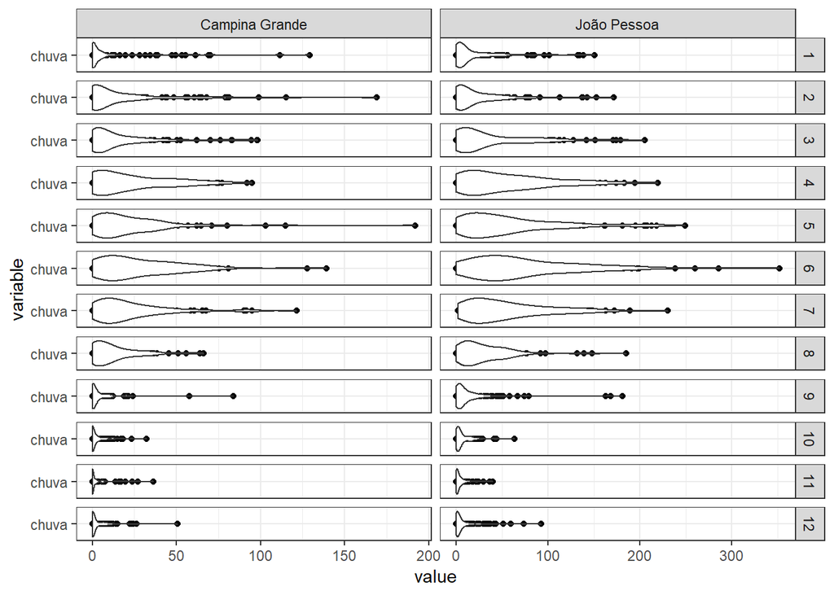

```r
ggplot(climas_long, aes(x=value, y=variable)) + geom_point() + geom_violinh() + facet_grid(mes~cidade, scales="free_x")
```